# Caso_Rotacion_Cargo

# Caso Rotación de Persona

En una organización, se busca comprender y prever los factores que influyen en la rotación de empleados entre distintos cargos. La empresa ha recopilado datos históricos sobre el empleo de sus trabajadores, incluyendo variables como la antigüedad en el cargo actual, el nivel de satisfacción laboral, el salario actual, edad y otros factores relevantes. La gerencia planea desarrollar un modelo de regresión logística que permita estimar la probabilidad de que un empleado cambie de cargo en el próximo período y determinar cuales factores indicen en mayor proporción a estos cambios.

Con esta información, la empresa podrá tomar medidas proactivas para retener a su talento clave, identificar áreas de mejora en la gestión de recursos humanos y fomentar un ambiente laboral más estable y tranquilo. La predicción de la probabilidad de rotación de empleados ayudará a la empresa a tomar decisiones estratégicas informadas y a mantener un equipo de trabajo comprometido y satisfecho en sus roles actuales.

A continuación se describen los pasos que la gerencia ha propuesto para el análisis:

El conjunto de datos está compuesto por aproximadamente 23 variables, por lo que realizar un análisis detallado de cada una de ellas no resulta eficiente ni alineado con el objetivo del proyecto. En este contexto, se llevó a cabo un proceso de selección de variables orientado a identificar aquellas con mayor capacidad explicativa respecto a la rotación de empleados.

Este proceso se desarrolló a partir de dos enfoques complementarios. En primer lugar, se incorporó el criterio de negocio, identificando variables que, desde la perspectiva de la gestión del talento humano, podrían estar relacionadas con la rotación, tales como las condiciones laborales, el tipo de cargo y las características individuales de los empleados. En segundo lugar, se realizó una exploracion estadística preliminar, mediante el cual se evaluó la relación individual entre cada variable y la variable objetivo, permitiendo priorizar aquellas con mayor evidencia de asociación.

La combinación de estos enfoques permitió realizar una selección más robusta, evitando depender exclusivamente del criterio subjetivo o de los resultados estadísticos aislados. Como resultado, se seleccionaron seis variables para el análisis detallado, distribuidas en tres categóricas y tres numéricas, lo que permite abordar el fenómeno de rotación desde diferentes dimensiones y facilita una interpretación más clara en las etapas posteriores del análisis y modelado.

# Análisis Descriptivo Univariado

### Distribución del Ingreso Mensual

La distribución del ingreso mensual revela una asimetría positiva o sesgo a la derecha, comportamiento esperado y común en variables salariales dentro de cualquier organización. La mayor concentración de empleados se ubica en el rango de 2.000 a 3.000, con aproximadamente 360 personas, lo que indica que la mayoría de la plantilla percibe salarios relativamente bajos. A medida que el ingreso aumenta, la frecuencia disminuye de forma sostenida, reflejando la estructura jerárquica típica de una empresa donde los salarios altos corresponden a una minoría. En este sentido, la mediana resulta una medida más representativa que la media, ya que esta última tiende a inflarse por los valores extremos del extremo superior. Adicionalmente, se observa un repunte en el rango de 19.000 a 20.000, que responde de forma natural a la presencia de cargos de mayor jerarquía como directores y ejecutivos, quienes representan una proporción pequeña pero diferenciada dentro de la organización. Dado este comportamiento asimétrico, se utilizará la variable **log_ingresos** en el modelo, transformación que ya fue aplicada durante el preprocesamiento y que permite estabilizar la varianza y mejorar el ajuste de la regresión logística.

[interactive chart not shown]

### Distribución del Antigüedad en el cargo

La distribución de la antigüedad en el cargo muestra que la mayor proporción de empleados se concentra en los rangos de 2 a 3 años (34.5%) y 6 o más años (35.5%), lo que sugiere la coexistencia de dos grupos predominantes: empleados relativamente recientes y empleados con alta permanencia en la organización. Por otro lado, se observa una menor participación en el rango de 4 a 5 años (9.5%), lo que podría indicar una posible transición o reducción en ese tramo intermedio. Asimismo, el 20.5% de los empleados presenta una antigüedad de 0 a 1 año, lo que refleja una proporción relevante de personal con corta permanencia. En conjunto, estos patrones evidencian una distribución no uniforme de la antigüedad, lo que podría ser consistente con dinámicas de rotación o retención diferenciadas, aunque sin permitir inferir causas específicas en esta etapa del análisis.

[interactive chart not shown]

### Distribución de la Satisfaccion Laboral

La distribución de la satisfacción laboral muestra que la mayor proporción de empleados se concentra en los niveles 3 (30.1%) y 4 (31.2%), lo que indica una tendencia general hacia niveles de satisfacción relativamente altos dentro de la organización. Por otro lado, los niveles más bajos de satisfacción, correspondientes a 1 (19.7%) y 2 (19.0%), presentan una menor participación, aunque en conjunto representan cerca del 40% de los empleados. En términos generales, la variable evidencia una distribución inclinada hacia valores altos, sin presentar concentraciones extremas en un solo nivel, lo que sugiere una dispersión moderada en los niveles de satisfacción laboral.

[interactive chart not shown]

### Distribucion Horas Extras - Fuerte

[interactive chart not shown]

### Distribucion del Cargo

La distribución por cargo evidencia que la mayor proporción de empleados se concentra en los roles de Ejecutivo de Ventas (22.2%), Investigador Científico (19.9%) y Técnico de Laboratorio (17.6%), los cuales en conjunto representan una parte significativa de la población analizada. En contraste, otros cargos como Director de Manufactura (9.9%) y Representante de Salud (8.9%) presentan una participación intermedia, mientras que posiciones como Gerente (6.9%), Representante de Ventas (5.6%), Director de Investigación (5.4%) y Recursos Humanos (3.5%) muestran una menor proporción relativa. En general, la variable presenta una distribución heterogénea, con una clara concentración en ciertos cargos operativos y comerciales, y una menor representación en roles directivos o especializados.

[interactive chart not shown]

### Distribucion de viaje de negocios

La distribución de los viajes de negocios muestra que la mayoría de los empleados, equivalente al 71%, realiza viajes de manera rara vez, lo que indica que esta es la condición predominante dentro de la organización. Por otro lado, el 18.8% de los empleados viaja frecuentemente, mientras que una proporción menor, correspondiente al 10.2%, no realiza viajes de negocio. En conjunto, la variable presenta una clara concentración en la categoría intermedia, con menor participación en los extremos, lo que sugiere que la mayor parte del personal tiene una exposición ocasional a desplazamientos laborales.

[interactive chart not shown]

# Analisis Bivariado

### Distribucion Horas extras / rotacion

El análisis bivariado entre la variable horas extra y la rotación revela una diferencia significativa en las proporciones de salida entre los grupos. En los empleados que no realizan horas extra, la proporción de rotación es de 10.4%, mientras que en aquellos que sí realizan horas adicionales asciende a 30.5%. Esta diferencia de aproximadamente 20 puntos porcentuales sugiere una asociación relevante entre la realización de horas extra y la probabilidad de rotación. No obstante, dado el carácter descriptivo del análisis, estos resultados no permiten establecer una relación causal, sino únicamente evidenciar un patrón diferenciado entre los grupos.

[interactive chart not shown]

### Distribucion Satisfaccion Laboral / rotacion

El análisis de la rotación según el nivel de satisfacción laboral evidencia una relación inversa entre ambas variables. A medida que aumenta el nivel de satisfacción, la proporción de empleados que rotan tiende a disminuir, mientras que la permanencia en la organización se incrementa. En los niveles más bajos de satisfacción se observa una mayor proporción de rotación, mientras que en los niveles más altos predomina la no rotación. Este patrón sugiere que la satisfacción laboral podría estar asociada con la decisión de permanencia de los empleados, mostrando una tendencia consistente a lo largo de los distintos niveles.

[interactive chart not shown]

### Distribucion Cargo / rotacion

El análisis de la rotación según el cargo evidencia diferencias relevantes entre los distintos roles dentro de la organización. En general, algunos cargos presentan mayores niveles de rotación en parte debido a su mayor representación en la plantilla, lo que incrementa la probabilidad de observar salidas en términos absolutos. Sin embargo, destaca el caso de Recursos Humanos, donde se observa una proporción relativamente alta de rotación en comparación con otros cargos, lo que sugiere un comportamiento distinto al esperado por su tamaño. Asimismo, cargos como Representante de Ventas y Técnico de Laboratorio también muestran niveles elevados de rotación, mientras que otros roles, como Gerente o Director de Investigación, presentan proporciones más bajas. En conjunto, estos resultados indican que la rotación no se distribuye de manera uniforme entre los cargos, evidenciando posibles diferencias en dinámicas laborales o condiciones asociadas a cada rol.

[interactive chart not shown]

#Crago vs Horas extras vs Rotacion

```r
library(htmltools)

tabla_cruce <- data %>%
  count(cargo, horas_extra, rotacion) %>%
  mutate(
    rotacion_label = ifelse(rotacion == 0, "No rotación", "Sí rotación")
  )

cargo_levels <- sort(unique(data$cargo))

grafico_cargo_hextra <- function(valor_horas_extra) {

  df_filtrado <- tabla_cruce %>%
    filter(horas_extra == valor_horas_extra)

  no_rot <- df_filtrado %>%
    filter(rotacion_label == "No rotación") %>%
    arrange(cargo) %>%
    pull(n)

  si_rot <- df_filtrado %>%
    filter(rotacion_label == "Sí rotación") %>%
    arrange(cargo) %>%
    pull(n)

  highchart() %>%
    hc_chart(type = "column") %>%
    hc_title(text = paste("Horas extra:", valor_horas_extra)) %>%
    hc_xAxis(
      categories = cargo_levels,
      title = list(text = "Cargo"),
      labels = list(rotation = -45)
    ) %>%
    hc_yAxis(
      labels = list(format = "{value:.0%}"),
      title = list(text = "Proporción")
    ) %>%
    hc_plotOptions(
      column = list(
        stacking = "percent",
        dataLabels = list(
          enabled = TRUE,
          format = "{point.percentage:.1f}%"
        )
      )
    ) %>%
    hc_add_series(name = "No rotación", data = no_rot) %>%
    hc_add_series(name = "Sí rotación", data = si_rot) %>%
    hc_tooltip(
      pointFormat = "<b>{series.name}:</b> {point.percentage:.2f}%"
    )
}

browsable(
  tagList(
    tags$h2("Rotación por cargo y horas extra"),
    grafico_cargo_hextra("No"),
    tags$br(),
    grafico_cargo_hextra("Si")
  )
)
```

## Rotación por cargo y horas extra

[interactive chart not shown]

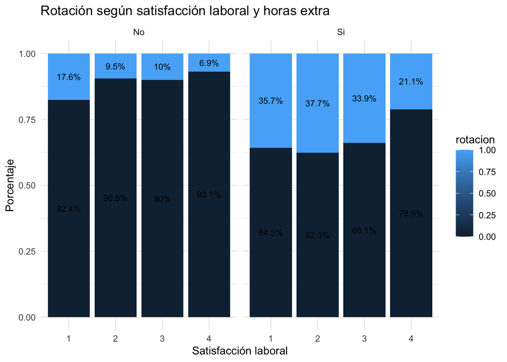

```r
# Tabla de proporciones
tabla_satisfaccion <- data %>%
  count(horas_extra, satisfaccion_laboral, rotacion) %>%
  group_by(horas_extra, satisfaccion_laboral) %>%
  mutate(porcentaje = n / sum(n)) %>%
  ungroup()

# Gráfica
ggplot(tabla_satisfaccion, aes(x = satisfaccion_laboral, y = porcentaje, fill = rotacion)) +
  geom_col(position = "fill") +
  facet_wrap(~ horas_extra) +
  geom_text(
    aes(label = paste0(round(porcentaje * 100, 1), "%")),
    position = position_fill(vjust = 0.5),
    size = 3
  ) +
  labs(
    title = "Rotación según satisfacción laboral y horas extra",
    x = "Satisfacción laboral",
    y = "Porcentaje"
  ) +
  theme_minimal()
```

```r
df_viaje <- data %>%
  count(viaje_de_negocios, rotacion) %>%
  mutate(
    rotacion_label = ifelse(rotacion == 0, "No rotación", "Sí rotación")
  )


viaje_levels <- levels(data$viaje_de_negocios)

no_rot <- df_viaje %>%
  filter(rotacion_label == "No rotación") %>%
  arrange(viaje_de_negocios) %>%
  pull(n)

si_rot <- df_viaje %>%
  filter(rotacion_label == "Sí rotación") %>%
  arrange(viaje_de_negocios) %>%
  pull(n)

highchart() %>%
  hc_chart(type = "column") %>%
  hc_plotOptions(
    column = list(
      stacking = "percent",
      dataLabels = list(
        enabled = TRUE,
        format = "{point.percentage:.1f}%"
      )
    )
  ) %>%
  hc_title(text = "Proporción de rotación según viajes de negocios") %>%
  hc_xAxis(
    categories = viaje_levels,
    title = list(text = "Viajes de negocios")
  ) %>%
  hc_yAxis(
    labels = list(format = "{value:.0%}"),
    title = list(text = "Proporción")
  ) %>%
  hc_add_series(
    name = "No rotación",
    data = no_rot
  ) %>%
  hc_add_series(
    name = "Sí rotación",
    data = si_rot
  ) %>%
  hc_tooltip(
    pointFormat = "<b>{series.name}:</b> {point.percentage:.2f}%"
  )
```

[interactive chart not shown]

```r
df_campo <- data %>%
  count(campo_educacion, rotacion) %>%
  mutate(
    rotacion_label = ifelse(rotacion == 0, "No rotación", "Sí rotación")
  )

campo_levels <- sort(unique(as.character(data$campo_educacion)))

no_rot_campo <- df_campo %>%
  filter(rotacion_label == "No rotación") %>%
  arrange(campo_educacion) %>%
  pull(n)

si_rot_campo <- df_campo %>%
  filter(rotacion_label == "Sí rotación") %>%
  arrange(campo_educacion) %>%
  pull(n)

highchart() %>%
  hc_chart(type = "column") %>%
  hc_plotOptions(
    column = list(
      stacking = "percent",
      dataLabels = list(
        enabled = TRUE,
        format = "{point.percentage:.1f}%"
      )
    )
  ) %>%
  hc_title(text = "Proporción de rotación según campo de educación") %>%
  hc_xAxis(
    categories = campo_levels,
    title = list(text = "Campo de educación"),
    labels = list(rotation = -45)
  ) %>%
  hc_yAxis(
    labels = list(format = "{value:.0%}"),
    title = list(text = "Proporción")
  ) %>%
  hc_add_series(
    name = "No rotación",
    data = no_rot_campo
  ) %>%
  hc_add_series(
    name = "Sí rotación",
    data = si_rot_campo
  ) %>%
  hc_tooltip(
    pointFormat = "<b>{series.name}:</b> {point.percentage:.2f}%"
  )
```

[interactive chart not shown]

```
## tibble [1,470 × 27] (S3: tbl_df/tbl/data.frame)
##  $ rotacion                   : Factor w/ 2 levels "0","1": 2 1 2 1 1 1 1 1 1 1 ...
##  $ edad                       : num [1:1470] 41 49 37 33 27 32 59 30 38 36 ...
##  $ viaje_de_negocios          : Factor w/ 3 levels "No_Viaja","Raramente",..: 2 3 2 3 2 3 2 2 3 2 ...
##  $ departamento               : Factor w/ 3 levels "Ventas","IyD",..: 1 2 2 2 2 2 2 2 2 2 ...
##  $ distancia_casa             : num [1:1470] 1 8 2 3 2 2 3 24 23 27 ...
##  $ educacion                  : num [1:1470] 2 1 2 4 1 2 3 1 3 3 ...
##  $ campo_educacion            : Factor w/ 6 levels "Ciencias","Otra",..: 1 1 2 1 3 1 3 1 1 3 ...
##  $ satisfaccion_ambiental     : Factor w/ 4 levels "1","2","3","4": 2 3 4 4 1 4 3 4 4 3 ...
##  $ genero                     : Factor w/ 2 levels "F","M": 1 2 2 1 2 2 1 2 2 2 ...
##  $ cargo                      : Factor w/ 9 levels "Director_Investigación",..: 3 5 9 5 9 9 9 9 2 7 ...
##  $ satisfaccion_laboral       : Factor w/ 4 levels "1","2","3","4": 4 2 3 3 2 4 1 3 3 3 ...
##  $ estado_civil               : Factor w/ 3 levels "Soltero","Casado",..: 1 2 1 2 2 1 2 3 1 2 ...
##  $ ingreso_mensual            : num [1:1470] 5993 5130 2090 2909 3468 ...
##  $ trabajos_anteriores        : num [1:1470] 8 1 6 1 9 0 4 1 0 6 ...
##  $ horas_extra                : Factor w/ 2 levels "No","Si": 2 1 2 2 1 1 2 1 1 1 ...
##  $ porcentaje_aumento_salarial: num [1:1470] 11 23 15 11 12 13 20 22 21 13 ...
##  $ rendimiento_laboral        : Factor w/ 4 levels "1","2","3","4": 3 4 3 3 3 3 4 4 4 3 ...
##  $ anos_experiencia           : num [1:1470] 8 10 7 8 6 8 12 1 10 17 ...
##  $ capacitaciones             : num [1:1470] 0 3 3 3 3 2 3 2 2 3 ...
##  $ equilibrio_trabajo_vida    : num [1:1470] 1 3 3 3 3 2 2 3 3 2 ...
##  $ antiguedad                 : num [1:1470] 6 10 0 8 2 7 1 1 9 7 ...
##  $ antiguedad_cargo           : num [1:1470] 4 7 0 7 2 7 0 0 7 7 ...
##  $ anos_ultima_promocion      : num [1:1470] 0 1 0 3 2 3 0 0 1 7 ...
##  $ anos_acargo_con_mismo_jefe : num [1:1470] 5 7 0 0 2 6 0 0 8 7 ...
##  $ log_ingresos               : num [1:1470] 8.7 8.54 7.65 7.98 8.15 ...
##  $ satisfaccion_laboral_num   : num [1:1470] 4 2 3 3 2 4 1 3 3 3 ...
##  $ cargo_grupo                : Factor w/ 4 levels "Otros","RH","Tec.lab",..: 4 1 3 1 3 3 3 3 1 1 ...
```

```
##                       variable       tipo      p_value coeficiente odds_ratio
## 1                  horas_extra Categorica 1.349094e-19       1.327      3.771
## 2                 log_ingresos   Numerica 1.412782e-13      -0.905      0.404
## 3             anos_experiencia   Numerica 1.689970e-10      -0.078      0.925
## 4             antiguedad_cargo   Numerica 1.606285e-09      -0.146      0.864
## 5                         edad   Numerica 1.897589e-09      -0.052      0.949
## 6              ingreso_mensual   Numerica 4.119147e-09       0.000      1.000
## 7   anos_acargo_con_mismo_jefe   Numerica 4.260546e-09      -0.141      0.868
## 8                  cargo_grupo Categorica 1.953818e-08       1.071      2.919
## 9                 estado_civil Categorica 2.535440e-08      -1.117      0.327
## 10                  antiguedad   Numerica 4.028505e-07      -0.081      0.922
## 11                       cargo Categorica 1.502160e-05       3.248     25.740
## 12        satisfaccion_laboral Categorica 3.588553e-05      -0.840      0.432
## 13           viaje_de_negocios Categorica 5.363748e-05       1.339      3.815
## 14      satisfaccion_ambiental Categorica 5.903822e-05      -0.782      0.458
```

[output cut: 39 more lines]

```r
modeloo <- glm(rotacion ~ edad + antiguedad_cargo + ingresos +
              genero + satisfaccion_laboral + rendimiento_laboral,
              data = data,
              family = binomial)

modelo_nuevo <- glm(
  rotacion ~ horas_extra + estado_civil + departamento +
    antiguedad_cargo + anos_acargo_con_mismo_jefe + ingresos +
    campo_educacion,
  data = data,
  family = binomial
)

modelo_nuevo3 <- glm(
  rotacion ~ horas_extra + cargo_grupo + viaje_de_negocios + satisfaccion_laboral_num + log_ingresos + antiguedad_cargo ,
  data = data,
  family = binomial
)

modelo_nuevo2 <- glm(
  rotacion ~ horas_extra + log_ingresos + viaje_de_negocios +
    distancia_casa + cargo + antiguedad,
  data = data,
  family = binomial
)

summary(modelo_nuevo3)
```

```
##
## Call:
## glm(formula = rotacion ~ horas_extra + cargo_grupo + viaje_de_negocios +
##     satisfaccion_laboral_num + log_ingresos + antiguedad_cargo,
##     family = binomial, data = data)
##
## Coefficients:
##                                 Estimate Std. Error z value Pr(>|z|)
## (Intercept)                      4.00738    1.33589   3.000 0.002702 **
## horas_extraSi                    1.53848    0.16189   9.503  < 2e-16 ***
## cargo_grupoRH                    0.77221    0.38874   1.986 0.046987 *
## cargo_grupoTec.lab               0.78721    0.21814   3.609 0.000308 ***
## cargo_grupoVentas                1.08312    0.18825   5.754 8.73e-09 ***
## viaje_de_negociosRaramente       0.62061    0.32889   1.887 0.059167 .
## viaje_de_negociosFrecuentemente  1.34233    0.35103   3.824 0.000131 ***
## satisfaccion_laboral_num        -0.32394    0.07026  -4.610 4.02e-06 ***
## log_ingresos                    -0.75227    0.15545  -4.839 1.30e-06 ***
## antiguedad_cargo                -0.09615    0.02776  -3.463 0.000534 ***
## ---
## Signif. codes:  0 '***' 0.001 '**' 0.01 '*' 0.05 '.' 0.1 ' ' 1
##
## (Dispersion parameter for binomial family taken to be 1)
##
##     Null deviance: 1298.6  on 1469  degrees of freedom
## Residual deviance: 1059.5  on 1460  degrees of freedom
## AIC: 1079.5
##
## Number of Fisher Scoring iterations: 5
```

```r
#summary(modelo_nuevo)

# AIC(modeloo, modelo_nuevo, modelo_nuevo2, modelo_nuevo3)
# anova(modeloo, modelo_nuevo, modelo_nuevo2, modelo_nuevo3, test = "Chisq")
#
#
# tabla_modelo_ord <- tidy(modeloo) %>%
#   filter(term != "(Intercept)") %>%
#   mutate(
#     coeficiente = round(estimate, 3),
#     error_std = round(std.error, 3),
#     z_value = round(statistic, 3),
#     odds_ratio = round(exp(estimate), 3),
#     p_num = p.value,
#     p_value = ifelse(p.value < 0.0001, "<0.0001", format(round(p.value, 4), nsmall = 4)),
#     efecto = case_when(
#       estimate > 0 ~ "Aumenta rotación",
#       estimate < 0 ~ "Reduce rotación",
#       TRUE ~ "Sin cambio"
#     ),
#     importancia = case_when(
#       p.value < 0.001 ~ "Muy fuerte",
#       p.value < 0.05 ~ "Significativa",
#       p.value < 0.10 ~ "Marginal",
#       TRUE ~ "No significativa"
#     )
#   ) %>%
#   arrange(p_num) %>%
#   select(
#     variable = term,
#     coeficiente,
#     error_std,
#     z_value,
#     odds_ratio,
#     p_value,
#     efecto,
#     importancia
#   )

#tabla_modelo_ord
```

```r
#summary(data)

library(pROC)
# 1. Crear variable dentro del dataset
data$log_ingresos <- log(data$ingreso_mensual)

# 2. Dividir datos
set.seed(123)
train_index <- sample(1:nrow(data), 0.7 * nrow(data))

train <- data[train_index, ]
test  <- data[-train_index, ]

# 3. Ajustar modelo
modelo_train <- glm(
  rotacion ~ horas_extra + cargo_grupo + viaje_de_negocios + satisfaccion_laboral_num + log_ingresos + antiguedad_cargo  ,
  data = train,
  family = binomial
)

# 4. Predicciones
pred_train <- predict(modelo_train, newdata = train, type = "response")
pred_test  <- predict(modelo_train, newdata = test, type = "response")

# 5. Revisar longitudes
length(train$rotacion)
```

```
## [1] 1029
```

```r
length(pred_train)
```

```
## [1] 1029
```

```r
length(test$rotacion)
```

```
## [1] 441
```

```r
length(pred_test)
```

```
## [1] 441
```

```r
# 6. AUC
auc_train <- roc(response = train$rotacion, predictor = pred_train)$auc
auc_test  <- roc(response = test$rotacion, predictor = pred_test)$auc
auc_train
```

```
## Area under the curve: 0.7899
```

```r
auc_test
```

```
## Area under the curve: 0.7793
```